# Span of control, transaction costs, and the structure of production chains

Kikuchi, Nishimura, and Stachurski (2018)

José Ignacio González Rojas

j.i.gonzalez-rojas@lse.ac.uk

London School of Economics and Political Science

October 3, 2024

## Research question

What are the determinants of the number and size of firms and how are tasks allocated across firms in production chains coordinated by prices?

Coase’s (1937) explanation.

## Model

- Countable infinity of price-taking firms $i \in \{1, 2, \ldots\}$.
- Produce a single unit of a final good.

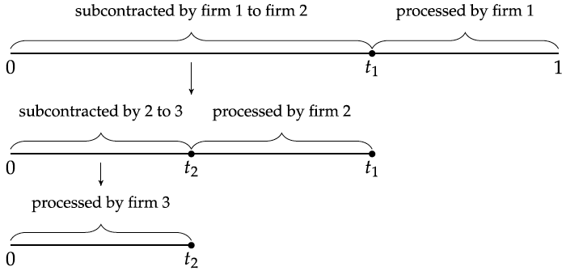

Recursive allocation of production tasks

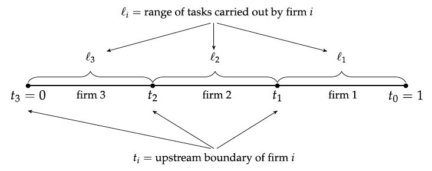

Notation

## Make-or-buy decision

- Firm chooses upstream boundary, i.e., how far to integrate backward into the input production.
- Firms face two types of costs:

### In-house production costs

- Diminishing returns to management.
- $c(\ell)$ is the cost of carrying out $\ell$ tasks in-house.
- $c(\cdot)$ is strictly increasing, strictly convex, and continuously differentiable.
- $c(0) = 0$, and $c'(0) > 0$ .

### Transaction costs

- Buying and selling through the market.
- Wedge $\delta > 1$ between buyer’s and seller’s prices. “Deadweight loss.”

## Equilibrium

Then, $(p, \mathbf{\ell})$ is an equilibrium for the production chain if

## Equilibrium exists and it’s unique

### Existence

**Constructive proof:**

#### Price function

$$T p(s) = \min_{t \in (0, s]} \{c(s-t) + \delta p(t)\} \; \forall s \in [0, 1]$$

The operator $T$ has a unique fixed point. Then, we’re done with $p^{*}(s)$.

#### Feasible allocation

Construct an allocation $\{\ell_{i}\}_{i \in \mathbb{N}}$ from the policy function $t^{*}(s)$.

## Equilibrium exists and it’s unique

#### Number of firms

$$n^{*} = \inf \{i \in \mathbb{N} | t^{*}_{i} = 0\} < \infty$$

then, $\{\ell_{i}\}_{i \in \mathbb{N}}$ is feasible and $(p, \mathbf{\ell})$ is an equilibrium for the production chain. $\square$

### Uniqueness

**Intuition:**

- Another price function should be large enough to sustain nonnegative profits. Then, inactive firms could enter the market and make profits. Therefore, we would have another allocation.
- Conversely, if there was another price function that sustains the allocation, it eliminates all profit opportunities. Hence, that price function would be lower than the optimal one.

## Features

### Price of the final good

The minimal cost of producing the whole product when all firms make zero profits and transaction costs cannot be avoided.
$$p^{*}(1) = c(\ell_{1}^{*}) + \delta c(\ell_{2}^{*}) + \cdots + \delta^{n-1} c(\ell_{n}^{*})$$

### Marginal conditions

#### Envelope condition

The marginal price of stage $s$ is equal to the marginal cost of the range of tasks carried on up to $s$.
$$p'^{*}(s) = c'^{*}(\ell^{*}(s))$$

## Features

### Marginal conditions

#### Coase-Euler equation

The marginal in-house cost per task at a given firm is equal to that of its upstream partner multiplied by gross transaction cost.
$$\delta c'^{*}(\ell^{*}_{i+1})= c'^{*}(\ell^{*}_{i})$$

### Downstream firms are always larger than upstream firms.

- Since the equilibrium price function is strictly convex, the marginal cost of these inputs rises as we move from upstream to downstream.
- Hence downstream firms choose to do more in-house.

## Comparative statics

The higher the transactions costs $\delta$,

### Higher price

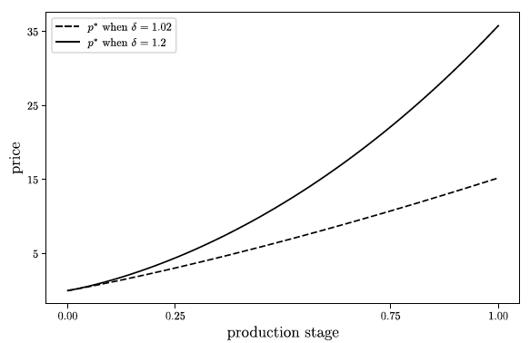

Price function

## Comparative statics

The higher the transactions costs $\delta$,

### Higher input integration

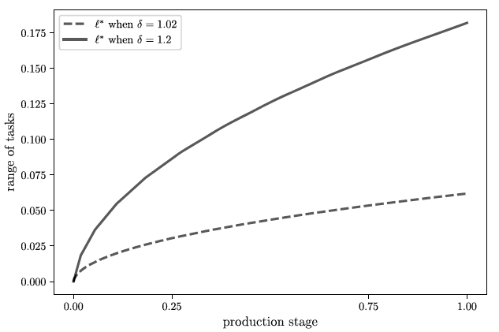

Optimal range of in-house tasks

## Comparative statics

The higher the transactions costs $\delta$,

### Lower number of firms

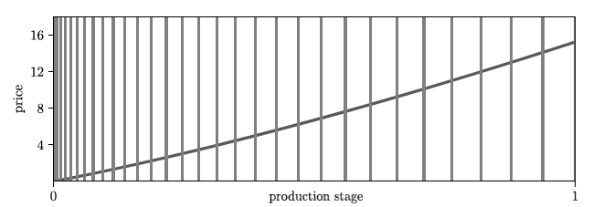

$\delta = 1.02$

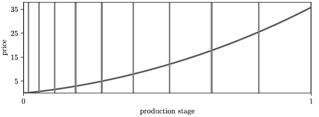

$\delta = 1.2$

Number of active firms

## Discussion

- Tractable and elegant model to study the structure of production chains, in particular, the boundaries of the firm.
- They have an extension with multiple upstream partners that generates realistic supply chain networks.
- The supply chain network structure is as rich as in the production networks literature, with ex-ante identical firms.